# Doing Meta-Analysis in R

Section 5 - 9

2024-02-27

# 1 Preparations

## 1.1 Packages

## 1.2 Environment

# 2 Between-Study Heterogeneity

## 2.1 Cochran’s Q

- $Q$ increases both when the number of studies $K$, and when the precision (i.e. the sample size of a study) increases. Therefore, $Q$ and whether it is significant highly depends on the size of your meta-analysis, and thus its statistical power.
- From this follows that we should not only rely on the significance of a $Q$-test when assessing heterogeneity.
- $\hat{\theta}$: the pooled effect according to the fixed-effect model.

$$Q = \sum^{K}_{k=1} \; w_k \; (\hat{\theta}_k - \hat{\theta})^2 \\
w_k = \frac{1}{s_k^2}$$
$\hat{\theta}$: the pooled effect according to the `fixed-effect` model.

Case 1: no-heterogeneity $\zeta_k = 0$ and the residuals $\hat{\theta_k} - \hat{\theta}$ are only product of the sampling error $\epsilon_k$.
$$\hat{\theta}_k - \hat{\theta} \sim N(0, \; 1)$$

```r
set.seed(2024)
error_fixed <- replicate(n = 10000, rnorm(40))
```

Case 2: heterogeneity Reference: https://bookdown.org/MathiasHarrer/Doing_Meta_Analysis_in_R/pooling-es.html#rem
$$\hat{\theta}_k - \hat{\theta} = \epsilon_k + \zeta_k$$

```r
set.seed(2024)
error_random <- replicate(n = 10000, rnorm(40) + rnorm(40))
```

Simplify the formula of $Q$ a little by assuming that the variance, and thus the weight $w_k$ of every study, is one, resulting in $w_k$ to drop out of the equation.

```r
set.seed(2024)
Q_fixed <- replicate(10000, sum(rnorm(40)^2))
Q_random <- replicate(10000, sum((rnorm(40) + rnorm(40))^2))
```

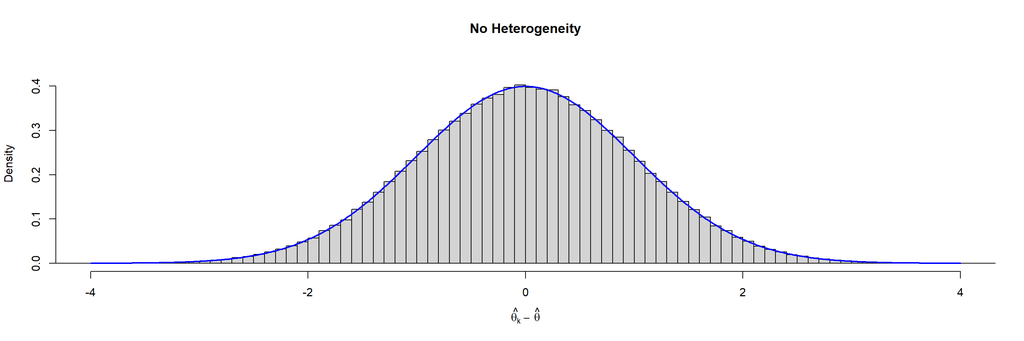

```r
hist(error_fixed,
     xlab = expression(hat(theta[k]) ~ - ~ hat(theta)), prob = TRUE,
     breaks = 100, ylim = c(0, .45), xlim = c(-4, 4),
     main = "No Heterogeneity")
lines(seq(-4, 4, 0.01), dnorm(seq(-4, 4, 0.01)),
      col = "blue", lwd = 2)
```

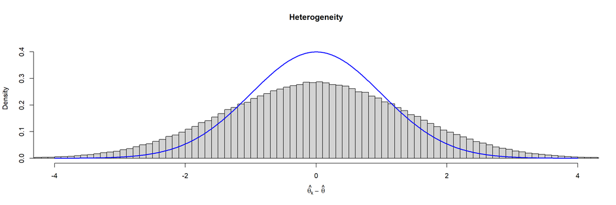

```r
hist(error_random,
     xlab = expression(hat(theta[k]) ~ - ~ hat(theta)), prob = TRUE,
     breaks = 100, ylim = c(0, .45), xlim = c(-4, 4),
     main = "Heterogeneity")
lines(seq(-4, 4, 0.01), dnorm(seq(-4, 4, 0.01)),
      col = "blue", lwd = 2)
```

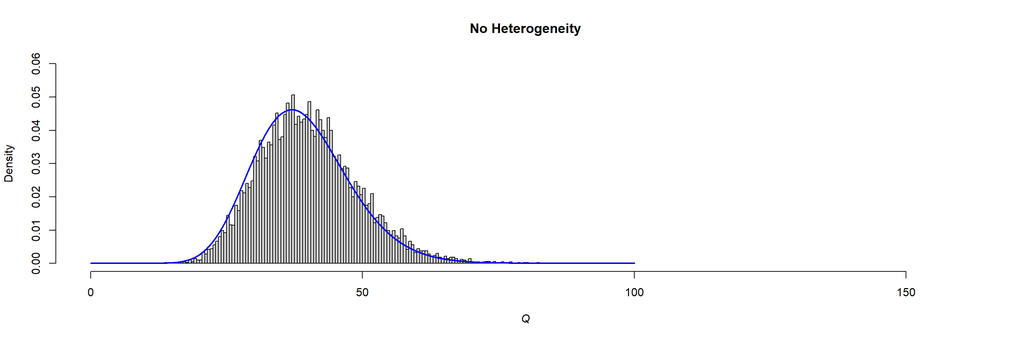

```r
df <- 40 - 1
hist(Q_fixed, xlab = expression(italic("Q")), prob = TRUE,
     breaks = 100, ylim = c(0, .06), xlim = c(0, 160),
     main = "No Heterogeneity")
lines(seq(0, 100, 0.01), dchisq(seq(0, 100, 0.01), df = df),
      col = "blue", lwd = 2)
```

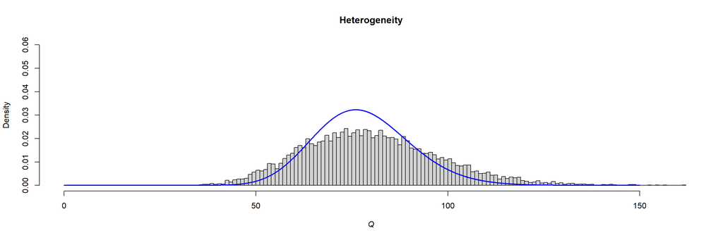

```r
hist(Q_random,  xlab = expression(italic("Q")), prob = TRUE,
     breaks = 100, ylim = c(0, .06), xlim = c(0, 160),
     main = "Heterogeneity")
lines(seq(0, 150, 0.01), dchisq(seq(0, 150, 0.01), df = df * 2),
      col = "blue", lwd = 2)
```

## 2.2 Higgins & Thompson’s I^2 Statistic

- Defined as the percentage of variability in the effect sizes that is not caused by sampling error.
- It quantifies, in percent, how much the observed value of $Q$ exceeds the expected $Q$ value when there is no heterogeneity (i.e. K - 1)
  $$I^2 = \frac{Max\{Q - (K - 1), \; 0\}}{Q} \ge 0$$

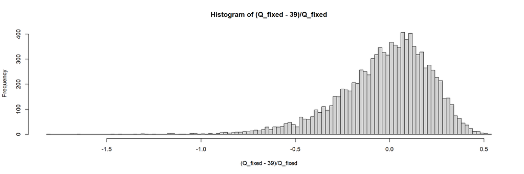

```r
hist((Q_fixed - 39) / Q_fixed, breaks = 100)
```

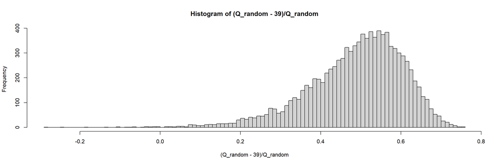

```r
hist((Q_random - 39) / Q_random, breaks = 100)
```

## 2.3 The H^2 Statistic

- A little more elegant than the one of $I^2$, because we do not have to artificially correct its value when $Q$ is smaller than $K - 1$.
- Values greater than one indicate the presence of between-study heterogeneity.
- Compared to $I^2$, it is far less common to find this statistic reported in published meta-analyses.
  $$H^2 = \frac{Q}{K-1}$$

## 2.4 Q-Profile

- The Q-Profile method is based on an altered $Q$ version, the generalized Q-statistic $Q_{gen}$.
- While the standard version of $Q$ uses the pooled effect based on the fixed-effect model, $Q_{gen}$ is based on the random-effects model.
- $\hat{u}$: the overall effect according to the random-effects model
- The Q-Profile method can be specified in `meta` functions through the argument `method.tau.ci = "QP"`. This is the default setting.
- $Q_{gen}(\tilde{\tau}^2)$ is calculated repeatedly while increasing the value of $\tau^2$, until the expected value of the lower and upper bound of the confidence interval based on the $\chi^2$ distribution ($K-1$ DoF) is reached.

$$Q_{gen} = \sum^{K}_{k=1} \; w_k^* \; (\hat{\theta}_k - \hat{u})^2 \\
w_k^* = \frac{1}{s_k^2 \; + \; \tau^2}$$

## 2.6 Assesing Heterogeneity in R

```r
data(ThirdWave)
m.gen <- metagen(TE = TE,
                 seTE = seTE,
                 studlab = Author,
                 data = ThirdWave,
                 sm = "SMD",
                 fixed = FALSE,
                 random = TRUE,
                 method.tau = "REML",
                 method.random.ci = "HK",
                 title = "Third Wave Psychotherapies")
```

```r
m.gen <- update(m.gen, prediction = TRUE)
summary(m.gen)
```

```
## Review:     Third Wave Psychotherapies
##
##                           SMD            95%-CI %W(random)
## Call et al.            0.7091 [ 0.1979; 1.2203]        5.0
## Cavanagh et al.        0.3549 [-0.0300; 0.7397]        6.3
## DanitzOrsillo          1.7912 [ 1.1139; 2.4685]        3.8
## de Vibe et al.         0.1825 [-0.0484; 0.4133]        7.9
## Frazier et al.         0.4219 [ 0.1380; 0.7057]        7.3
## Frogeli et al.         0.6300 [ 0.2458; 1.0142]        6.3
## Gallego et al.         0.7249 [ 0.2846; 1.1652]        5.7
## Hazlett-Stevens & Oren 0.5287 [ 0.1162; 0.9412]        6.0
## Hintz et al.           0.2840 [-0.0453; 0.6133]        6.9
## Kang et al.            1.2751 [ 0.6142; 1.9360]        3.9
## Kuhlmann et al.        0.1036 [-0.2781; 0.4853]        6.3
## Lever Taylor et al.    0.3884 [-0.0639; 0.8407]        5.6
## Phang et al.           0.5407 [ 0.0619; 1.0196]        5.3
## Rasanen et al.         0.4262 [-0.0794; 0.9317]        5.1
## Ratanasiripong         0.5154 [-0.1731; 1.2039]        3.7
## Shapiro et al.         1.4797 [ 0.8618; 2.0977]        4.2
## Song & Lindquist       0.6126 [ 0.1683; 1.0569]        5.7
## Warnecke et al.        0.6000 [ 0.1120; 1.0880]        5.2
##
## Number of studies: k = 18
##
##                              SMD            95%-CI    t  p-value
## Random effects model (HK) 0.5771 [ 0.3782; 0.7760] 6.12 < 0.0001
## Prediction interval              [-0.0572; 1.2115]
##
## Quantifying heterogeneity:
##  tau^2 = 0.0820 [0.0295; 0.3533]; tau = 0.2863 [0.1717; 0.5944]
##  I^2 = 62.6% [37.9%; 77.5%]; H = 1.64 [1.27; 2.11]
##
## Test of heterogeneity:
##      Q d.f. p-value
##  45.50   17  0.0002
##
## Details on meta-analytical method:
## - Inverse variance method
## - Restricted maximum-likelihood estimator for tau^2
## - Q-Profile method for confidence interval of tau^2 and tau
## - Hartung-Knapp adjustment for random effects model (df = 17)
## - Prediction interval based on t-distribution (df = 16)
```

## 2.7 Outliers and Influential Cases

- Assessing the robustness of our pooled results: outlier and influence analyses.

### 2.7.1 Basic Outlier Removal

- View a study as an outlier if its confidence interval does not overlap with the confidence interval of the pooled effect.

# 3 Power Analysis

```r
power.analysis(
    d = 0.2,
    k = 10,
    n1 = 25,
    n2 = 25,
    p = 0.05
)
```

```
## Fixed-effect model used.
```

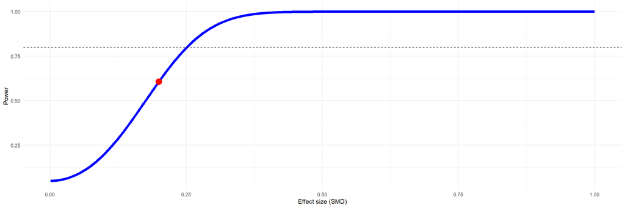

```
## Power: 60.66%
```

```r
power.analysis(
    d = 0.5,
    k = 10,
    n1 = 25,
    n2 = 25,
    p = 0.05,
    heterogeneity = "moderate"
)
```

```
## Random-effects model used (moderate heterogeneity assumed).
```

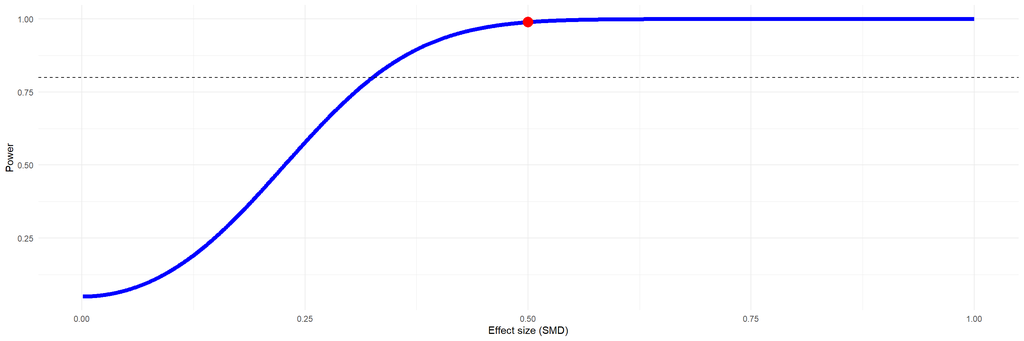

```
## Power: 98.93%
```

# 4 References

- https://bookdown.org/MathiasHarrer/Doing_Meta_Analysis_in_R/
- Bakbergenuly, Ilyas, David C. Hoaglin, and Elena Kulinskaya. 2020. “Methods for Estimating Between-Study Variance and Overall Effect in Meta-Analysis of Odds Ratios.” Research Synthesis Methods 11(3): 426–42. doi:10.1002/jrsm.1404.